# Pertemuan 6 dan 7

Davina Rachmadyanti

2023-10-15

Diagnostik dan Peramalan

Libraries

```r
library(ggplot2)
library(tsibble)
library(tseries)
library(MASS)
library(forecast)
library(TSA)
library(TTR)
library(aTSA)
library(graphics)
```

Input Data

```r
data<-rio::import("https://raw.githubusercontent.com/davinarachmadyanti/mpdw/main/Data/Data.csv")

#Mengambil hanya kolom Close sebagai data baru
dataclose <- data$Close
dataclose
```

```
##   [1] 2860 2810 2890 2690 2680 2730 2750 2630 2620 2830 2990 3220 3460 3250 3280
##  [16] 3510 3320 3310 3570 3480 3390 3110 3290 3190 3210 3490 3320 3450 3440 3490
##  [31] 3390 3360 3360 3310 3200 3190 3180 3270 3270 3500 3470 3350 3250 3070 3160
##  [46] 3170 3170 3240 3320 3300 3400 3320 3390 3330 3530 3560 3660 3800 3810 3870
##  [61] 3800 3770 3600 3900 4010 4070 4150 4100 4110 4040 4170 4190 4330 4260 4230
##  [76] 4450 4400 4340 4400 4590 4540 4520 4580 4580 4680 4620 4620 4620 4260 4170
##  [91] 4300 4310 4020 4120 4150 4020 4010 4150 4230 4230 4650 4550 4600 4490 4600
## [106] 4600 4410 4380 4460 4350 4290 4360 4450 4210 4150 4010 4030 4000 3650 3680
## [121] 3780 3750 3710 3780 3870 3960 3880 3800 3760 4040 3900 4010 4050 4070 4060
## [136] 4250 4340 4270 4250 4170 3980 4020 4130 4040 4150 3970 3950 4000 3960 3930
## [151] 3860 3720 3690 3810 3760 3720 3720 3720
```

```r
#Mengganti tipe data menjadi time series
dataclose.ts<-ts(dataclose)
```

Eksplorasi Data

Plot untuk Seluruh Data

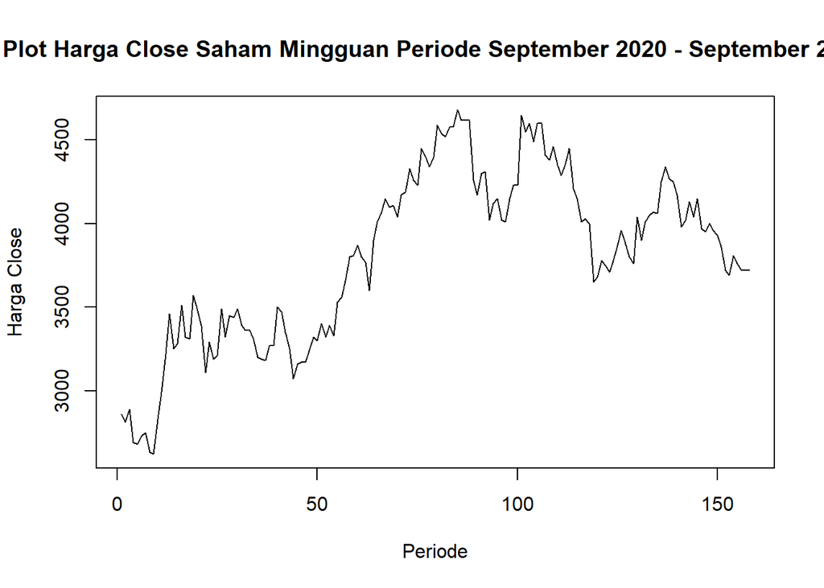

```r
plot.ts(dataclose.ts, xlab="Periode", ylab="Harga Close", main="Plot Harga Close Saham Mingguan Periode September 2020 - September 2023")
```

Plot Data Train

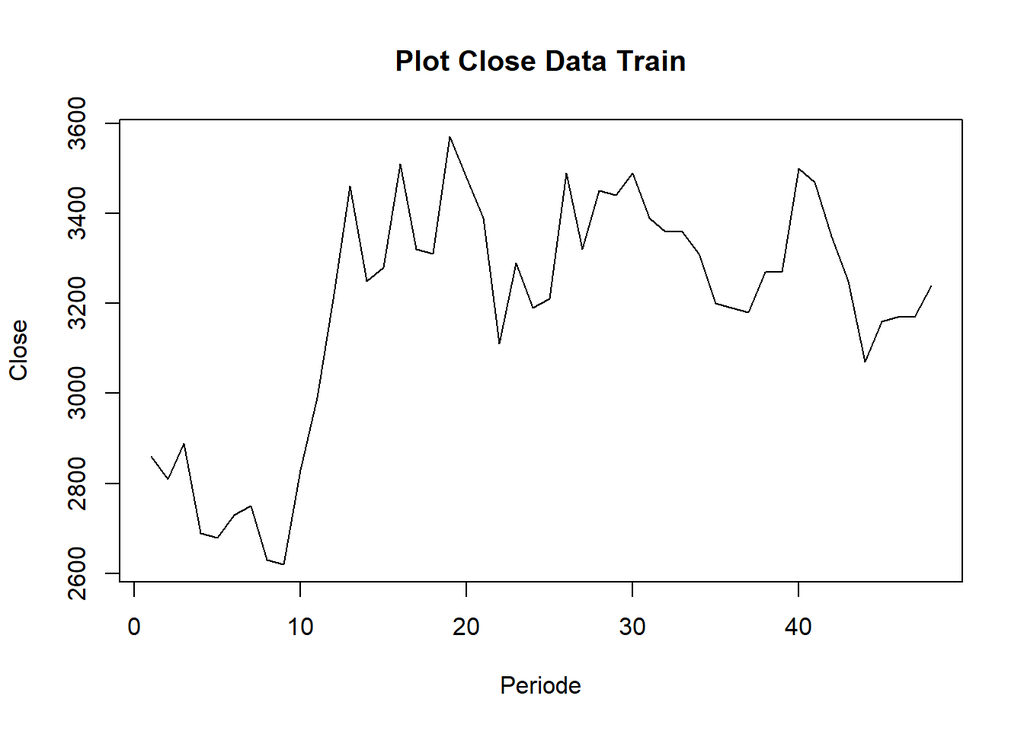

```r
datatrain<-dataclose[1:48]
train.ts<-ts(datatrain)
plot.ts(train.ts, lty=1, xlab="Periode", ylab="Close", main="Plot Close Data Train")
```

Plot data train mengindikasikan data tidak stasioner dalam rataan maupun ragam

Plot Data Test

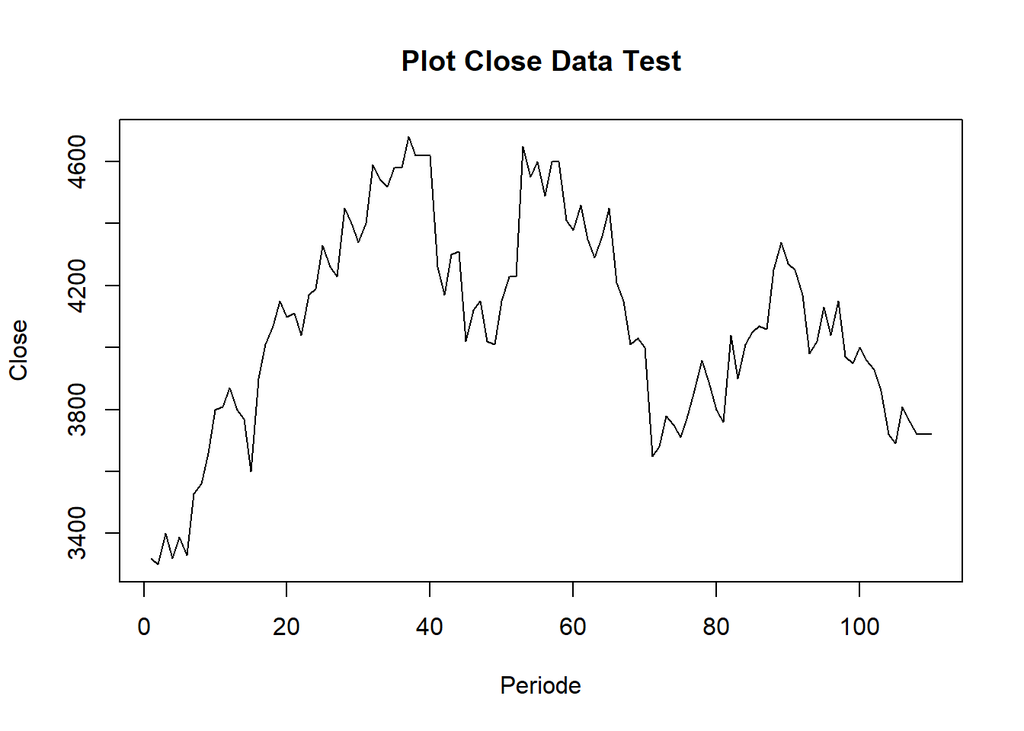

```r
datatest<-dataclose[49:158]
test.ts<-ts(datatest)
plot.ts(test.ts, lty=1, xlab="Periode", ylab="Close", main="Plot Close Data Test")
```

Plot data test mengindikasikan data tidak stasioner dalam rataan maupun ragam. Selanjutnya akan dilihat sifat stasioner data train melalui plot ACF, Uji ADF, dan plot Box-Cox

Kestasioneran Data

Plot ACF

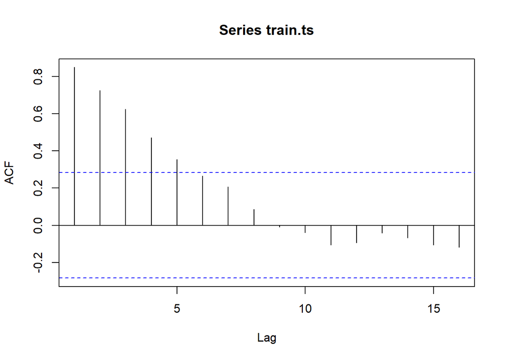

```r
acf(train.ts)
```

Plot ACF di atas menampilkan bahwa data menurun secara perlahan, artinya data diindikasi tidak stasioner dalam rataan.

Uji ADF

H0: Data tidak stasioner dalam rataan H1: Data stasioner dalam rataan

```r
tseries::adf.test(train.ts)
```

```
##
##  Augmented Dickey-Fuller Test
##
## data:  train.ts
## Dickey-Fuller = -2.2285, Lag order = 3, p-value = 0.4829
## alternative hypothesis: stationary
```

Berdasarkan hasil uji ADF, diperoleh p-value sebesar 0.4829 > 0.05. Hal ini menunjukkan keputusan terima H0, artinya data tidak stasioner dalam rataan. Hasil ini sesuai dengan hasil yang diperoleh ketika melalukan eksplorasi dengan plot time series serta plot ACF.

Plot Box-Cox

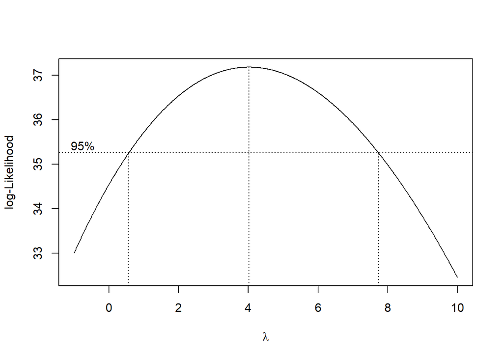

```r
index <- seq(1:48)
bc = boxcox(train.ts~index, lambda = seq(-1,10,by=0.01))
```

```r
#Nilai Rounded Lambda
lambda <- bc$x[which.max(bc$y)]
lambda
```

```
## [1] 4.02
```

```r
#SK
bc$x[bc$y > max(bc$y) - 1/2 * qchisq(.95,1)]
```

```
##   [1] 0.58 0.59 0.60 0.61 0.62 0.63 0.64 0.65 0.66 0.67 0.68 0.69 0.70 0.71 0.72
##  [16] 0.73 0.74 0.75 0.76 0.77 0.78 0.79 0.80 0.81 0.82 0.83 0.84 0.85 0.86 0.87
##  [31] 0.88 0.89 0.90 0.91 0.92 0.93 0.94 0.95 0.96 0.97 0.98 0.99 1.00 1.01 1.02
##  [46] 1.03 1.04 1.05 1.06 1.07 1.08 1.09 1.10 1.11 1.12 1.13 1.14 1.15 1.16 1.17
##  [61] 1.18 1.19 1.20 1.21 1.22 1.23 1.24 1.25 1.26 1.27 1.28 1.29 1.30 1.31 1.32
##  [76] 1.33 1.34 1.35 1.36 1.37 1.38 1.39 1.40 1.41 1.42 1.43 1.44 1.45 1.46 1.47
##  [91] 1.48 1.49 1.50 1.51 1.52 1.53 1.54 1.55 1.56 1.57 1.58 1.59 1.60 1.61 1.62
## [106] 1.63 1.64 1.65 1.66 1.67 1.68 1.69 1.70 1.71 1.72 1.73 1.74 1.75 1.76 1.77
## [121] 1.78 1.79 1.80 1.81 1.82 1.83 1.84 1.85 1.86 1.87 1.88 1.89 1.90 1.91 1.92
## [136] 1.93 1.94 1.95 1.96 1.97 1.98 1.99 2.00 2.01 2.02 2.03 2.04 2.05 2.06 2.07
## [151] 2.08 2.09 2.10 2.11 2.12 2.13 2.14 2.15 2.16 2.17 2.18 2.19 2.20 2.21 2.22
## [166] 2.23 2.24 2.25 2.26 2.27 2.28 2.29 2.30 2.31 2.32 2.33 2.34 2.35 2.36 2.37
## [181] 2.38 2.39 2.40 2.41 2.42 2.43 2.44 2.45 2.46 2.47 2.48 2.49 2.50 2.51 2.52
## [196] 2.53 2.54 2.55 2.56 2.57 2.58 2.59 2.60 2.61 2.62 2.63 2.64 2.65 2.66 2.67
## [211] 2.68 2.69 2.70 2.71 2.72 2.73 2.74 2.75 2.76 2.77 2.78 2.79 2.80 2.81 2.82
```

[output cut: 33 more lines]

Plot Boxcox menunjukkan nilai lambda (λ) optimum sebesar 4.02. Pada selang kepercayaan 95% nilai memiliki batas bawah 0.58 dan batas atas 7.72. Selang tersebut memuat nilai satu sehingga dapat dikatakan bahwa data yang digunakan stasioner dalam ragam.

Penanganan Ketakstasioneran Data

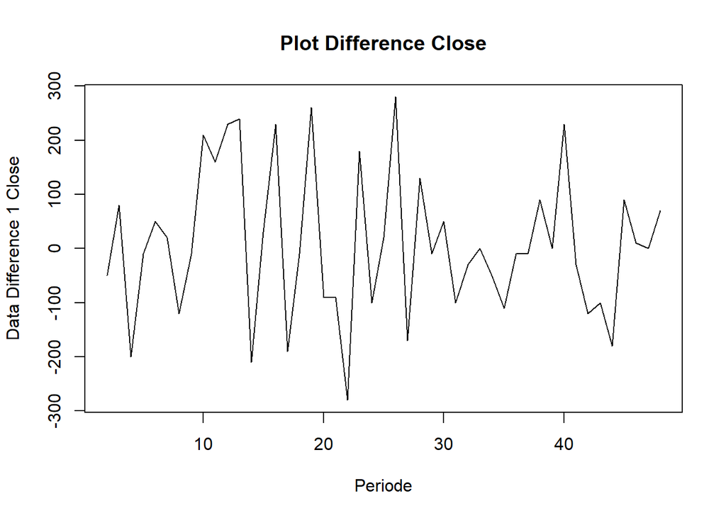

```r
train.diff<-diff(train.ts,differences = 1)
plot.ts(train.diff, lty=1, xlab="Periode", ylab="Data Difference 1 Close", main="Plot Difference Close")
```

Terlihat bahwa data cenderung telah stasioner dalam rataan. Selanjutnya akan dilakukan uji kestasioneran data menggunakan plot ACF dan Uji ADF.

Plot ACF

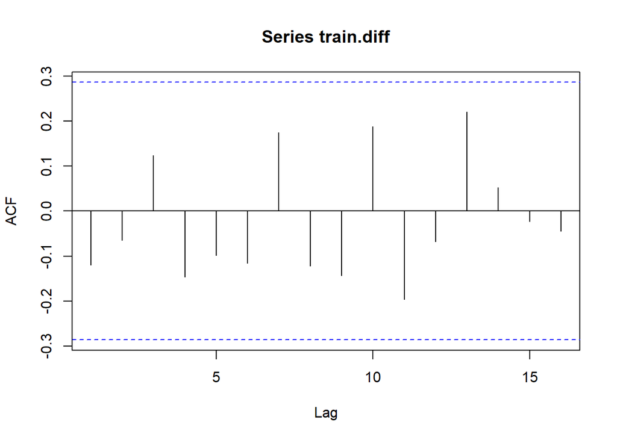

```r
acf(train.diff)
```

Terlihat bahwa data tidak lagi menurun secara perlahan. Hal ini menunjukkan data telah stasioner dalam rataan

Uji ADF

H0: Data tidak stasioner dalam rataan H1: Data stasioner dalam rataan

```r
tseries::adf.test(train.diff)
```

```
##
##  Augmented Dickey-Fuller Test
##
## data:  train.diff
## Dickey-Fuller = -3.7755, Lag order = 3, p-value = 0.02894
## alternative hypothesis: stationary
```

Berdasarkan hasil uji ADF, diperoleh p-value sebesar 0.0289 < 0.05. Hal ini menunjukkan keputusan tolak H0, artinya data stasioner dalam rataan. Kestidakstasioneran data telah tertangani, selanjutnya akan dilakukan identifikasi model

Identifikasi Model

Plot ACF

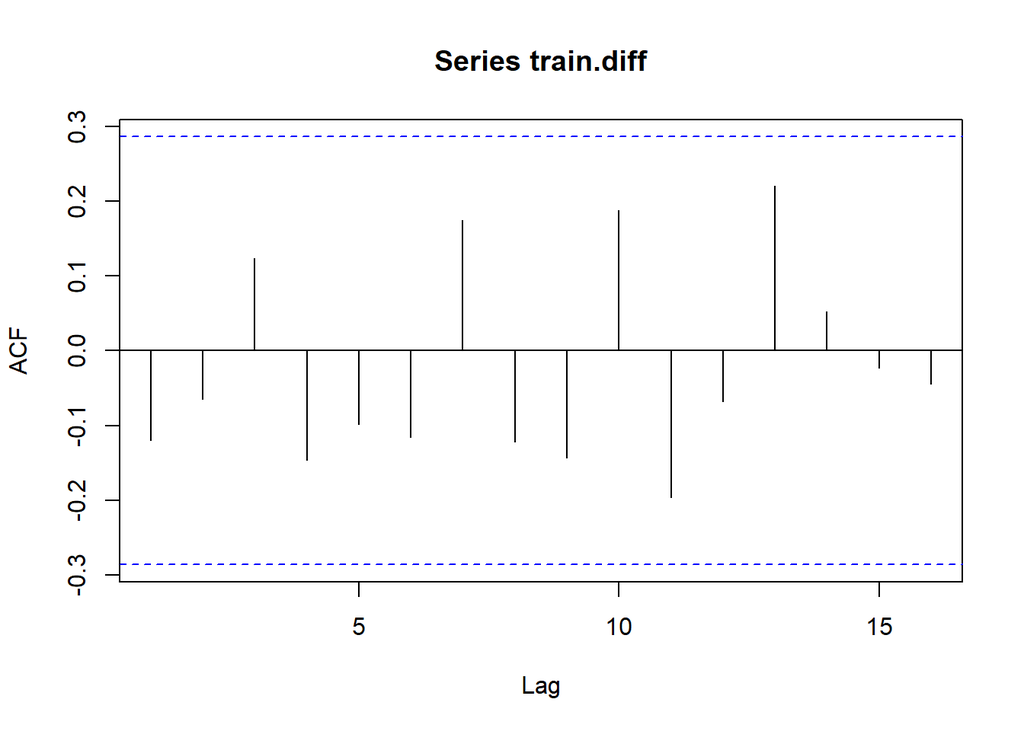

```r
acf(train.diff)
```

Identifikasi model menggunakan plot ACF tidak menampilkan data cuts off di lag mana pun.

Plot PACF

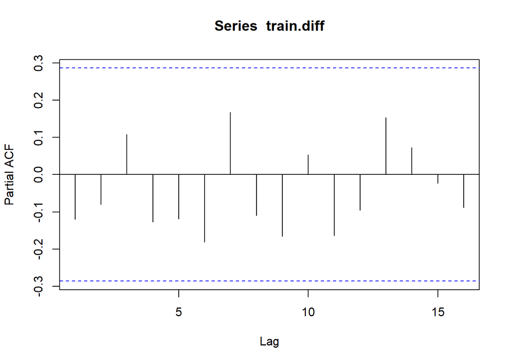

```r
pacf(train.diff)
```

Identifikasi model menggunakan plot PACF tidak menampilkan data cuts off di lag mana pun.

Plot EACF

```r
eacf(train.diff)
```

```
## AR/MA
##   0 1 2 3 4 5 6 7 8 9 10 11 12 13
## 0 o o o o o o o o o o o  o  o  o
## 1 x o o o o o o o o o o  o  o  o
## 2 x o o o o o o o o o o  o  o  o
## 3 x o o o o o o o o o o  o  o  o
## 4 x o o x o o o o o o o  o  o  o
## 5 x o x x o o o o o o o  o  o  o
## 6 x o o x o o o o o o o  o  o  o
## 7 x o x o o o o o o o o  o  o  o
```

Identifikasi model menggunakan plot menunjukkan model tentatif yang terbentuk adalah ARIMA(0,1,0), ARIMA(1,1,0), dan ARIMA(1,1,1)

Pendugaan Parameter Model Tentatif

ARIMA(0,1,0)

```r
model1.da=Arima(train.diff, order=c(0,1,0),method="ML")
summary(model1.da) #AIC=622.27
```

```
## Series: train.diff
## ARIMA(0,1,0)
##
## sigma^2 = 42039:  log likelihood = -310.14
## AIC=622.27   AICc=622.37   BIC=624.1
##
## Training set error measures:
##                    ME     RMSE      MAE MPE MAPE    MASE       ACF1
## Training set 2.552128 202.8415 157.8734 NaN  Inf 0.97873 -0.5205295
```

Diperoleh nilai AIC sebesar 622.27

ARIMA(1,1,0)

```r
model2.da=Arima(train.diff, order=c(1,1,0),method="ML")
summary(model2.da) #AIC=609.87
```

```
## Series: train.diff
## ARIMA(1,1,0)
##
## Coefficients:
##           ar1
##       -0.5150
## s.e.   0.1241
##
## sigma^2 = 31209:  log likelihood = -302.93
## AIC=609.87   AICc=610.15   BIC=613.53
##
## Training set error measures:
##                    ME    RMSE      MAE MPE MAPE      MASE       ACF1
## Training set 2.704966 172.862 127.8647 NaN  Inf 0.7926922 -0.2450397
```

```r
lmtest::coeftest(model2.da) #seluruh parameter signifikan
```

```
##
## z test of coefficients:
##
##     Estimate Std. Error z value  Pr(>|z|)
## ar1 -0.51505    0.12414 -4.1488 3.342e-05 ***
## ---
## Signif. codes:  0 '***' 0.001 '**' 0.01 '*' 0.05 '.' 0.1 ' ' 1
```

Diperoleh nilai AIC sebesar 609.87 dengan seluruh parameter signifikan

ARIMA(1,1,1)

```r
model3.da=Arima(train.diff, order=c(1,1,1),method="ML")
summary(model3.da) #AIC=592.77
```

```
## Series: train.diff
## ARIMA(1,1,1)
##
## Coefficients:
##           ar1      ma1
##       -0.0990  -1.0000
## s.e.   0.1467   0.0811
##
## sigma^2 = 19428:  log likelihood = -293.38
## AIC=592.77   AICc=593.34   BIC=598.25
##
## Training set error measures:
##                     ME     RMSE      MAE  MPE MAPE      MASE        ACF1
## Training set -2.125654 134.8637 106.9274 -Inf  Inf 0.6628922 -0.02206616
```

```r
lmtest::coeftest(model3.da) #hanya parameter ma1 yang signifikan
```

```
##
## z test of coefficients:
##
##      Estimate Std. Error  z value Pr(>|z|)
## ar1 -0.099028   0.146736  -0.6749   0.4998
## ma1 -0.999998   0.081146 -12.3234   <2e-16 ***
## ---
## Signif. codes:  0 '***' 0.001 '**' 0.01 '*' 0.05 '.' 0.1 ' ' 1
```

Diperoleh nilai AIC sebesar 592.77 dengan hanya parameter ma1 signifikan

ARIMA(0,1,2)

```r
model4.da=Arima(train.diff, order=c(0,1,2),method="ML")
summary(model4.da) #AIC=592.73
```

```
## Series: train.diff
## ARIMA(0,1,2)
##
## Coefficients:
##           ma1     ma2
##       -1.1068  0.1068
## s.e.   0.1717  0.1503
##
## sigma^2 = 19396:  log likelihood = -293.36
## AIC=592.73   AICc=593.3   BIC=598.22
##
## Training set error measures:
##                     ME     RMSE     MAE  MPE MAPE      MASE        ACF1
## Training set -2.207244 134.7507 106.801 -Inf  Inf 0.6621085 -0.01387845
```

```r
lmtest::coeftest(model4.da) #hanya parameter ma1 signifikan
```

```
##
## z test of coefficients:
##
##     Estimate Std. Error z value  Pr(>|z|)
## ma1 -1.10682    0.17173 -6.4453 1.154e-10 ***
## ma2  0.10682    0.15030  0.7108    0.4772
## ---
## Signif. codes:  0 '***' 0.001 '**' 0.01 '*' 0.05 '.' 0.1 ' ' 1
```

Diperoleh nilai AIC sebesar 592.73 dengan hanya parameter ma1 signifikan

ARIMA(0,1,1)

```r
model5.da=Arima(train.diff, order=c(0,1,1),method="ML")
summary(model5.da) #AIC=591.22
```

```
## Series: train.diff
## ARIMA(0,1,1)
##
## Coefficients:
##           ma1
##       -1.0000
## s.e.   0.0718
##
## sigma^2 = 19265:  log likelihood = -293.61
## AIC=591.22   AICc=591.5   BIC=594.88
##
## Training set error measures:
##                     ME     RMSE      MAE  MPE MAPE      MASE       ACF1
## Training set -1.433457 135.8134 107.9225 -Inf  Inf 0.6690613 -0.1125957
```

```r
lmtest::coeftest(model5.da) #seluruh parameter signifikan
```

```
##
## z test of coefficients:
##
##      Estimate Std. Error z value  Pr(>|z|)
## ma1 -0.999999   0.071802 -13.927 < 2.2e-16 ***
## ---
## Signif. codes:  0 '***' 0.001 '**' 0.01 '*' 0.05 '.' 0.1 ' ' 1
```

Pendugaan parameter beberapa model tentatif di atas, menunjukkan nilai AIC terkecil dimiliki oleh model ARIMA(0,1,1) dengan seluruh parameter signifikan, sehingga model yang dipilih adalah model ARIMA(0,1,1).

Analisis Sisaan

Eksplorasi Sisaan

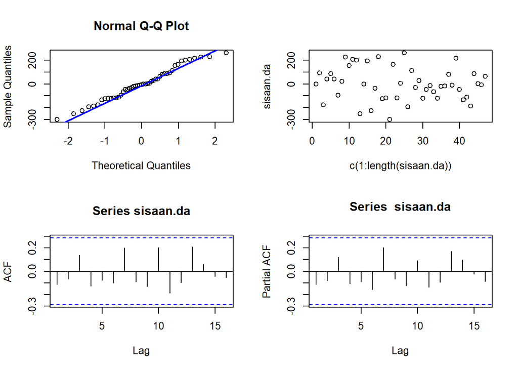

```r
#Eksplorasi
sisaan.da <- model5.da$residuals
par(mfrow=c(2,2))
qqnorm(sisaan.da)
qqline(sisaan.da, col = "blue", lwd = 2)
plot(c(1:length(sisaan.da)),sisaan.da)
acf(sisaan.da)
pacf(sisaan.da)
```

Berdasarkan QQ plot, secara eksplorasi ditunjukkan sisaan menyebar normal ditandai dengan titik titik yang cenderung mengikuti garis 45 derajat. Kemudian dapat dilihat juga lebar pita sisaan yang cenderung sama menandakan bahwa sisaan memiliki ragam yang homogen. Plot ACF dan PACF sisaan ARIMA(0,1,1) juga tidak signifikan pada 15 lag awal yang menandakan saling bebas. Kondisi ini akan diuji lebih lanjut dengan uji formal.

Uji Formal

Uji normalitas Jarque Bera H0: Sisaan menyebar normal H1: Sisaan tidak menyebar normal

```r
#1) Sisaan Menyebar Normal
tseries::jarque.bera.test(sisaan.da)  #tak tolak H0 > sisaan menyebar normal
```

```
##
##  Jarque Bera Test
##
## data:  sisaan.da
## X-squared = 0.7424, df = 2, p-value = 0.6899
```

Berdasarkan hasil uji di atas, diperoleh p-value sebesar 0.6899 > 0.05 sehingga menunjukkan keputusan terima H0, artinya sisaan menyebar normal. Hal ini sesuai dengan hasil eksplorasi menggunakan plot kuantil-kuantil normal.

Uji Autokorelasi Ljung-Box H0: Sisaan saling bebas H1: Sisaan tidak tidak saling bebas

```r
#2) Sisaan saling bebas/tidak ada autokorelasi
Box.test(sisaan.da, type = "Ljung")  #tak tolak H0 > sisaan saling bebas
```

```
##
##  Box-Ljung test
##
## data:  sisaan.da
## X-squared = 0.63472, df = 1, p-value = 0.4256
```

Berdasarkan hasil uji di atas, diperoleh p-value sebesar 0.4256 > 0.05 sehingga menunjukkan keputusan terima H0, artinya sisaan saling bebas/ tidak ada autokorelasi.

Uji Homogenitas Sisaan Ljung Box H0: Ragam sisaan homogen H1: Ragam sisaan tidak homogen

```r
#3) Sisaan homogen
Box.test((sisaan.da)^2, type = "Ljung")  #tak tolak H0 > sisaan homogen
```

```
##
##  Box-Ljung test
##
## data:  (sisaan.da)^2
## X-squared = 0.31694, df = 1, p-value = 0.5735
```

Berdasarkan hasil uji di atas, diperoleh p-value sebesar 0.5735 > 0.05 sehingga menunjukkan keputusan terima H0, artinya sisaan homogen.

Uji nilai harapan sisaan = 0 H0: nilai tengah sisaan sama dengan 0 H1: nilai tengah sisaan tidak sama dengan 0

```r
#4) Nilai tengah sisaan sama dengan nol
t.test(sisaan.da, mu = 0, conf.level = 0.95)  #tak tolak h0 > nilai tengah sisaan sama dengan 0
```

```
##
##  One Sample t-test
##
## data:  sisaan.da
## t = -0.071589, df = 46, p-value = 0.9432
## alternative hypothesis: true mean is not equal to 0
## 95 percent confidence interval:
##  -41.73863  38.87172
## sample estimates:
## mean of x
## -1.433457
```

Berdasarkan hasil uji di atas, diperoleh p-value sebesar 0.9432 > 0.05 sehingga menunjukkan keputusan terima H0, artinya nilai tengah sisaan sama dengan nol.

```r
model.overfit1=Arima(train.diff, order=c(1,1,2),method="ML")
summary(model.overfit1) #594.72
```

```
## Series: train.diff
## ARIMA(1,1,2)
##
## Coefficients:
##          ar1      ma1     ma2
##       0.0994  -1.2048  0.2048
## s.e.  1.0772   1.0662  1.0629
##
## sigma^2 = 19833:  log likelihood = -293.36
## AIC=594.72   AICc=595.69   BIC=602.03
##
## Training set error measures:
##                     ME     RMSE      MAE  MPE MAPE      MASE       ACF1
## Training set -2.263497 134.7039 106.7724 -Inf  Inf 0.6619316 -0.0146902
```

```r
lmtest::coeftest(model.overfit1) #seluruh parameter tidak signifikan
```

```
##
## z test of coefficients:
##
##      Estimate Std. Error z value Pr(>|z|)
## ar1  0.099361   1.077196  0.0922   0.9265
## ma1 -1.204822   1.066161 -1.1301   0.2585
## ma2  0.204835   1.062884  0.1927   0.8472
```

ARIMA(0,1,2)

```r
model.overfit2=Arima(train.diff, order=c(0,1,2),method="ML")
summary(model.overfit2) #592.73
```

```
## Series: train.diff
## ARIMA(0,1,2)
##
## Coefficients:
##           ma1     ma2
##       -1.1068  0.1068
## s.e.   0.1717  0.1503
##
## sigma^2 = 19396:  log likelihood = -293.36
## AIC=592.73   AICc=593.3   BIC=598.22
##
## Training set error measures:
##                     ME     RMSE     MAE  MPE MAPE      MASE        ACF1
## Training set -2.207244 134.7507 106.801 -Inf  Inf 0.6621085 -0.01387845
```

```r
lmtest::coeftest(model.overfit2) #ma2 tidak signifikan
```

```
##
## z test of coefficients:
##
##     Estimate Std. Error z value  Pr(>|z|)
## ma1 -1.10682    0.17173 -6.4453 1.154e-10 ***
## ma2  0.10682    0.15030  0.7108    0.4772
## ---
## Signif. codes:  0 '***' 0.001 '**' 0.01 '*' 0.05 '.' 0.1 ' ' 1
```

Berdasarkan percobaan overfitting di atas, dipilih model awal yaitu, ARIMA(0,1,1)

Peramalan Peramalan dilakukan untuk 50 periode ke depan

```r
#---FORECAST---#
ramalan.da <- forecast::forecast(model5.da, h = 50)
ramalan.da
```

```
##    Point Forecast     Lo 80    Hi 80    Lo 95    Hi 95
## 49       8.085106 -171.6748 187.8451 -266.834 283.0042
## 50       8.085106 -171.6748 187.8451 -266.834 283.0042
## 51       8.085106 -171.6748 187.8451 -266.834 283.0042
## 52       8.085106 -171.6748 187.8451 -266.834 283.0042
## 53       8.085106 -171.6748 187.8451 -266.834 283.0042
## 54       8.085106 -171.6748 187.8451 -266.834 283.0042
## 55       8.085106 -171.6748 187.8451 -266.834 283.0042
## 56       8.085106 -171.6748 187.8451 -266.834 283.0042
## 57       8.085106 -171.6748 187.8451 -266.834 283.0042
## 58       8.085106 -171.6748 187.8451 -266.834 283.0042
## 59       8.085106 -171.6748 187.8451 -266.834 283.0042
## 60       8.085106 -171.6748 187.8451 -266.834 283.0042
## 61       8.085106 -171.6748 187.8451 -266.834 283.0042
## 62       8.085106 -171.6748 187.8451 -266.834 283.0042
```

[output cut: 36 more lines]

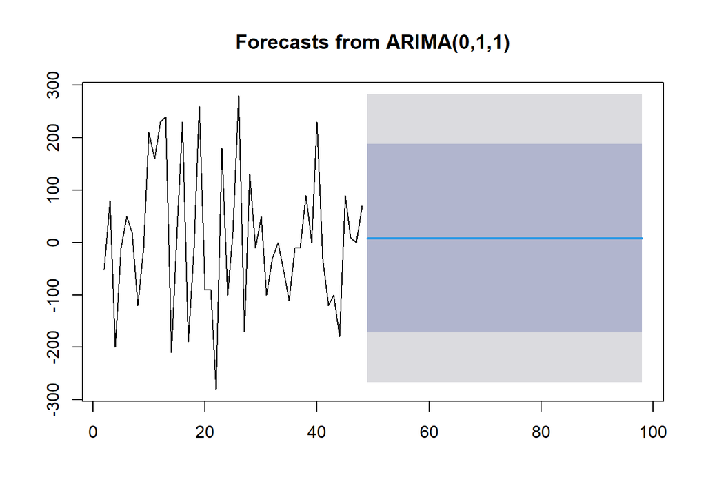

```r
data.ramalan.da <- ramalan.da$mean
plot(ramalan.da)
```

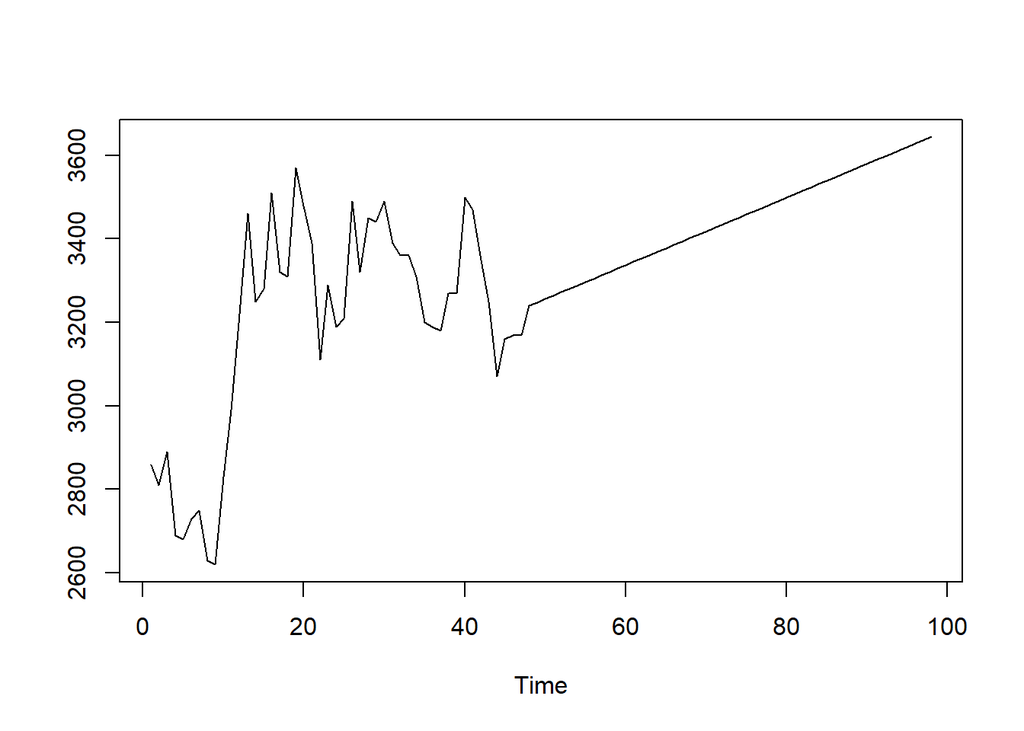

```r
pt_1 <- train.ts[48] #nilai akhir data latih
hasil.forc.Diff <- data.ramalan.da
hasil <- diffinv(hasil.forc.Diff, differences = 1) + pt_1

#has.1 sama hasilnta dengan: cumsum(c(pt_1,hasil.forc.Diff))
ts.plot(train.ts,hasil)
```

```r
perbandingan.da<-matrix(data=c(head(test.ts, n=50), hasil[-1]),
                     nrow = 50, ncol = 2)
colnames(perbandingan.da)<-c("Aktual","Hasil Forecast")
perbandingan.da
```

```
##       Aktual Hasil Forecast
##  [1,]   3320       3248.085
##  [2,]   3300       3256.170
##  [3,]   3400       3264.255
##  [4,]   3320       3272.340
##  [5,]   3390       3280.426
##  [6,]   3330       3288.511
##  [7,]   3530       3296.596
##  [8,]   3560       3304.681
##  [9,]   3660       3312.766
## [10,]   3800       3320.851
## [11,]   3810       3328.936
## [12,]   3870       3337.021
## [13,]   3800       3345.106
## [14,]   3770       3353.191
```

[output cut: 36 more lines]

```r
accuracy(ts(hasil[-1]), head(test.ts, n=30))
```

```
##                ME     RMSE      MAE      MPE     MAPE      ACF1 Theil's U
## Test set 508.3475 585.2561 508.3475 12.52556 12.52556 0.8714452  4.932748
```